# Tarea 6. Ecuaciones diferenciales ordinarias.

# Ejercicio 30

**Crecimiento logístico cruzado**

$$\begin{equation}
\begin{cases}
\frac{dx}{dt} = x(1 - x - 0.5y) \\
\frac{dy}{dt} = y(1 - y - 0.3x) \\
x(0) = 0.5,\quad y(0) = 0.2
\end{cases}
\end{equation}$$

**Código**

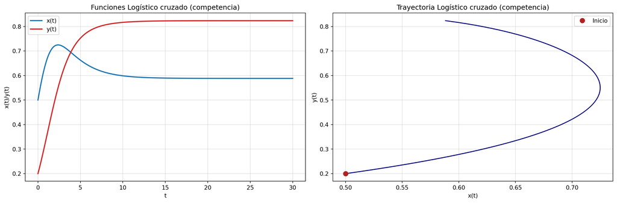

```python
def f30(t, U):
    x, y = U
    return [x*(1 - x - 0.5*y), y*(1 - y - 0.3*x)]

resolver_funciones_y_trayectoria(f30, 0, 30, [0.5, 0.2], ['x(t)', 'y(t)'],
                                 titulo='Logístico cruzado (competencia)');
```

Modelo de competencia entre dos especies: ambas crecen logísticamente pero también inhiben el crecimiento de la otra. El sistema tiende a un equilibrio de **coexistencia** porque los coeficientes cruzados $0.5$ y $0.3$ son menores que $1$.

# Ejercicio 31

**Movimiento en campo no lineal**

$$\begin{equation}
\begin{cases}
\frac{dx}{dt} = y \\
\frac{dy}{dt} = -\sin(x) - 0.5 y \\
x(0) = \pi/2,\quad y(0) = 0
\end{cases}
\end{equation}$$

**Código**

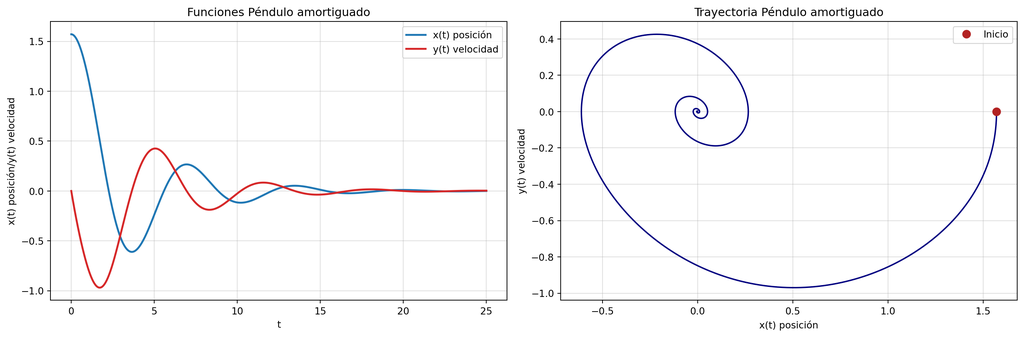

```python
def f31(t, U):
    x, y = U
    return [y, -np.sin(x) - 0.5*y]

resolver_funciones_y_trayectoria(f31, 0, 25, [np.pi/2, 0], ['x(t) posición', 'y(t) velocidad'],
                                 titulo='Péndulo amortiguado');
```

Equivale a un **péndulo amortiguado**: la trayectoria espirala hacia el equilibrio estable $(x,y)=(0,0)$ (péndulo en reposo en su posición más baja).

# Ejercicio 32

**Sistema no lineal acoplado**

$$\begin{equation}
\begin{cases}
\frac{dx}{dt} = x(1 - x) - xy^2 \\
\frac{dy}{dt} = y(1 - y) - x^2y \\
x(0) = 0.8,\quad y(0) = 0.6
\end{cases}
\end{equation}$$

**Código**

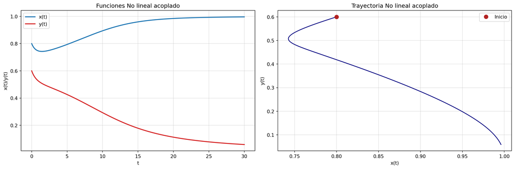

```python
def f32(t, U):
    x, y = U
    return [x*(1-x) - x*y**2, y*(1-y) - x**2*y]

resolver_funciones_y_trayectoria(f32, 0, 30, [0.8, 0.6], ['x(t)', 'y(t)'],
                                 titulo='No lineal acoplado');
```